Ficha del establecimiento

# Liceo Politécnico Ciencia Y Tecnología

RBD **9693**La CisternaEscuela o liceoTécnico Profesional

915estudiantes matriculadosCorte Agosto 2026

Mujeres39,0%357 est.

Hombres61,0%558 est.

Chilenos/as83,1%760 est.

Extranjeros/as16,9%155 est.

Actualizada al 05-10-2026

💻Ver ficha completaVersión para computador, con mapas y gráficos interactivos. Pesa varios MB: mejor ábrela con wifi.

🏛️Identificación

## Identificación del establecimiento

Los datos de contacto y las características básicas del establecimiento, tal como están registrados en el Ministerio de Educación. **Si algo está mal o falta, escríbenos** y lo corregimos en la próxima actualización.

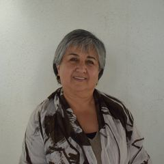

Director o directora

Jacqueline Del Carmen Muñoz Abarca (s)

**Nombre**

Liceo Politécnico Ciencia Y Tecnología

**RBD**

9693

**Dirección**

Avenida Goycolea 469

**Comuna**

La Cisterna

**Tipo**

Escuela o liceo

**Estado**

✅En funcionamiento

**Director/a**

Jacqueline Del Carmen Muñoz Abarca (s)

**Correo**

liceocienciaytecnologia@slepsantarosa.cl

**Teléfono**

443144700

**Sitio web**

WWW.LICEOCIENCIAYTECNOLOGIA.COM

**Matrícula**

GRATUITO

**Sostenedor**

El sostenedor corresponde a una persona jurídica

**Orientación**

Orientación religiosa Laica

### Niveles que imparte

✓ 📘 Media Humanístico-Científica Jóvenes✓ 🛠️ Media Técnico-Profesional/Artística Jóvenes

### Vulnerabilidad del alumnado

Índice de vulnerabilidad (IVE)

90,2%

Lo calcula JUNAEB y sirve para asignar programas de apoyo.

0%100%

Este establecimientoPromedio de la comuna 74%

Prioritarios en Media

91,0%

Estudiantes en 1ª, 2ª o 3ª prioridad.

**Un IVE más alto significa más necesidad de apoyo**, no peor calidad. Se usa para decidir a qué establecimientos llegan primero los programas de alimentación, salud y becas.

### Apoyos profesionales al aprendizaje

✓ 🧩 Psicopedagogo/a✓ 🧠 Psicólogo/a✓ 🧭 Orientador/a✓ 👩‍🏫 Profesor/a de educación especial✓ 🤝 Asistente social📚 Reforzamiento🎓 Orientación vocacional🗣️ Fonoaudiólogo/a➕ Otro

### Infraestructura y atención a la diversidad

✓ 📚 Biblioteca✓ 🔬 Laboratorio✓ 🌐 Computadores con internet✓ 💻 Computadores✓ 🖥️ Sala de informática✓ 📽️ Sala audiovisual✓ 🤾 Gimnasio✓ ♿ Accesibilidad NEE✓ ➕ Otra: LABORATORIO DE ESPECIALIDADES🏛️ Sala multiuso🏟️ Cancha deportiva

✓ 👁️ Discapacidad visual✓ 👂 Discapacidad auditiva✓ 🧠 Discapacidad intelectual✓ 🦽 Discapacidad motora🧩 Trastorno del espectro autista💬 Trastornos de la comunicación📖 Dificultades de aprendizaje🗣️ Trastorno específico del lenguaje🎯 Déficit atencional📊 Funcionamiento intelectual limítrofe

Las etiquetas con ✓ son las que el establecimiento declaró en el directorio oficial; las grises no están marcadas.

### Jornada Escolar Completa (JEC)

Cursos con jornada completa

Cursos sin jornada completa

0

**Ver curso por curso**

[output not shown]

Con **Jornada Escolar Completa** los estudiantes tienen más horas de clases al día y almuerzan en el establecimiento.

### Idiomas

**Inglés en Enseñanza Media**

Básico

### Certificación ambiental (SNCAE)

🌿Certificación ambiental nivel Básico

**Inicio de la certificación**

2023

**Término de la certificación**

2025

### Concentración de alumnado prioritario

Concentración 2026

66,1%

▼1,01 pts

Porcentaje de estudiantes prioritarios reconocidos por el Mineduc.

0%100%

Concentración del establecimiento

Concentración 2025

67,1%

Resolución exenta

2026

Observación del Ministerio: **Mantienen ACAP**.

La **concentración de prioritarios** define cuánta Subvención Escolar Preferencial (SEP) recibe el establecimiento. Sobre 60 % da acceso a la asignación por concentración.

### Requisitos para postular

✓ 🎂 Cumplir la edad mínima✓ 📄 Certificado de nacimiento✓ 📝 Informe de personalidad✓ ➕ Otro: NOTAS 1º SEMESTRE📊 Certificado de notas🏠 Ficha de protección social🧪 Test de intereses♿ Informe de necesidades educativas✍️ Firmar el proyecto educativo⚖️ Firmar el reglamento de convivencia📋 Examen de ingreso👥 Entrevista con apoderados🎲 Sorteo💍 Certificado de matrimonio⛪ Certificado de bautismo⛪ Certificado de matrimonio religioso💰 Pago de postulación

Desde el Sistema de Admisión Escolar, los establecimientos públicos **no pueden seleccionar** por rendimiento ni por antecedentes socioeconómicos. Estos son los antecedentes administrativos que el establecimiento declara pedir.

**Equipo del SLEP que acompaña al establecimiento**

**Asesor/a territorial**

DIEGO MENDOZA CISTERNAS

**Correo UTP**

utp.liceocienciaytecnologia@slepsantarosa.cl

**Correo Inspectoría**

inspectoria.liceocienciaytecnologia@slepsantarosa.cl

🏫Matrícula

## Matrícula y asistencia

Cuántos estudiantes tiene el establecimiento, quiénes son y cuántos días van efectivamente a clases. **La asistencia es el porcentaje de días que los estudiantes asistieron** sobre los días en que estuvieron matriculados.

Matrícula · Agosto 2026

915

▼1,2%

Variación desde el primer mes del año escolar.

1141.024

Este establecimientoPromedio del SLEP 333

Asistencia promedio

78,4%

Días asistidos sobre días matriculados.

47,8%98,5%

Este añoPromedio de años anteriores 77,9%

Cursos

32

Niveles

2

Matrícula regular

915

Estudiantes en la modalidad regular del establecimiento.

Matrícula no regular

0

Modalidades de adultos, reingreso o validación de estudios.

Matrícula mes a mes · 2026

Cuántos estudiantes había registrados al cierre de cada mes.

Asistencia mes a mes · 2026

Porcentaje de días asistidos sobre los días en que el estudiante estuvo matriculado.

Matrícula año a año

Matrícula del último mes de cada año escolar.

### Quiénes estudian acá

Por género

Hombres · 558Mujeres · 357

Por origen

Chilenos/as · 760Extranjeros/as · 155Nacionalizados/as · 0

Nacionalidades presentes

Número de estudiantes por país de nacimiento declarado.

🇻🇪 Venezolana48

🇨🇴 Colombiana12

🇵🇪 Peruana12

🇪🇨 Ecuatoriana7

🌐 Otra5

Otros11

Pueblos originarios

Estudiantes que declaran pertenecer a un pueblo originario.

🌿 Mapuche56

☀️ Aymara2

🏺 Diaguita1

### Por nivel de enseñanza

Matrícula por nivel

📘 Media Humanístico-Científica Jóvenes468

🛠️ Media Técnico-Profesional/Artística Jóvenes447

Asistencia por nivel

La escala va de 0 % a 100 %.

📘 Media Humanístico-Científica Jóvenes76,4%

🛠️ Media Técnico-Profesional/Artística Jóvenes80,6%

### Asistencia por grupo

Asistencia por género

Promedio ponderado por el número de estudiantes de cada grupo.

Hombres79,0%

Mujeres77,7%

Asistencia por origen

Chilenos/as77,4%

Extranjeros/as84,0%

Asistencia por nacionalidad

Solo los seis grupos con más estudiantes.

🇨🇱 Chilena77,8%

🇻🇪 Venezolana84,9%

🇨🇴 Colombiana88,1%

🇵🇪 Peruana88,1%

🇪🇨 Ecuatoriana28,6%

🌐 Otra87,6%

Asistencia por pueblo originario

🌿 Mapuche78,5%

☀️ Aymara76,2%

🏺 Diaguita0,0%

### Matrícula técnico-profesional

Estudiantes por especialidad

🔌 Electrónica117

📂 Administración114

📡 Telecomunicaciones111

🏭 Química industrial (con mención)105

Asistencia por especialidad

🔌 Electrónica0,0%

📂 Administración0,0%

📡 Telecomunicaciones0,0%

🏭 Química industrial (con mención)0,0%

**Ver el detalle curso por curso (32 cursos)**

| Curso | Matrícula | Asistencia % |
| --- | --- | --- |
| 1° Medio A | 31 | 68,7 |
| 1° Medio B | 32 | 79,4 |
| 1° Medio C | 23 | 77,1 |
| 1° Medio D | 19 | 80,3 |
| 1° Medio E | 29 | 76,5 |
| 1° Medio F | 27 | 75,1 |
| 1° Medio G | 30 | 76,1 |
| 1° Medio H | 32 | 70,7 |
| 2° Medio A | 35 | 80,5 |
| 2° Medio B | 36 | 79,6 |
| 2° Medio C | 24 | 71,6 |
| 2° Medio D | 26 | 74,4 |
| 2° Medio E | 26 | 82,4 |
| 2° Medio F | 31 | 80,9 |
| 2° Medio G | 31 | 79,2 |
| 2° Medio H | 36 | 70,9 |
| 3° Medio A | 32 | 80,8 |
| 3° Medio B | 34 | 87,1 |
| 3° Medio C | 33 | 75,9 |
| 3° Medio D | 29 | 71,9 |
| 3° Medio E | 32 | 86,3 |
| 3° Medio F | 28 | 80 |
| 3° Medio G | 32 | 81,8 |
| 3° Medio H | 31 | 71,6 |
| 4° Medio A | 27 | 83,7 |
| 4° Medio B | 21 | 75,1 |
| 4° Medio C | 28 | 81,8 |
| 4° Medio D | 27 | 84,7 |
| 4° Medio E | 26 | 85,7 |
| 4° Medio F | 22 | 84,8 |
| 4° Medio G | 23 | 84,1 |
| 4° Medio H | 22 | 73 |

**Ver la matrícula año a año, con su variación**

| Periodo | Matrícula | Variación | Cambio |
| --- | --- | --- | --- |
| 2026 | 915 | +37,0 | +4,2% |
| 2025 | 878 | +53,0 | +6,4% |
| 2024 | 825 | −24,0 | −2,8% |
| 2023 | 849 | −30,0 | −3,4% |
| 2022 | 879 | −151,0 | −14,7% |
| 2019 | 1.030 | −22,0 | −2,1% |
| 2018 | 1.052 | −44,0 | −4,0% |
| 2017 | 1.096 | −30,0 | −2,7% |
| 2016 | 1.126 | — | — |

**Ver la asistencia año a año, con su variación**

| Periodo | Asistencia | Variación | Cambio |
| --- | --- | --- | --- |
| 2026 | 78,4% | −16,6 pts | −17,5% |
| 2025 | 95,0% | +43,7 pts | +85,2% |
| 2024 | 51,3% | −27,6 pts | −35,0% |
| 2023 | 78,9% | +4,9 pts | +6,6% |
| 2022 | 74,0% | — | — |
| 2019 | — | — | — |
| 2018 | 79,5% | −7,4 pts | −8,5% |
| 2017 | 86,9% | +6,8 pts | +8,5% |
| 2016 | 80,1% | — | — |

La matrícula se cuenta al cierre de cada mes, así que los cambios durante el año reflejan traslados y retiros. Corte usado: **Agosto 2026**.

🤝Vida escolar

## Vida escolar y comunidad

Qué actividades ofrece el establecimiento fuera de las clases, cómo se organiza con las familias y quiénes representan a la comunidad. **Las etiquetas con ✓ son las que el establecimiento declaró** en el directorio oficial del Ministerio; las grises no están marcadas.

### Talleres y actividades para estudiantes

✓ 🧭 Orientación✓ 🤝 Convivencia✓ 🚫 Prevención drogas✓ ❤️ Educación sexual✓ 🌟 Vida sana✓ 🫂 Acción social🌱 Medio ambiente✝️ Pastoral➕ Otra

Actividades de formación: orientación, convivencia, prevención y vida sana.

✓ 🎵 Música✓ 🎓 Preuniversitario🎭 Teatro📚 Literatura✂️ Manualidades🩰 Danza o ballet🎨 Artes plásticas💻 Taller TIC➕ Otro

Talleres de arte, cultura y tecnología fuera del horario de clases.

✓ 🥅 Baby fútbol✓ 🏐 Vóleibol✓ 🏀 Básquetbol✓ 🏓 Tenis de mesa✓ ➕ Otro: CROSSFIT,DEFENSA PERSONAL,TAEKWONDO⚽ Fútbol🏃 Atletismo🏊 Natación🤸 Gimnasia🎾 Tenis♟️ Ajedrez

Disciplinas deportivas que ofrece el establecimiento.

### Trabajo con las familias

✓ 👪 Talleres de formación🎉 Actividades de integración📈 Perfeccionamiento➕ Otra

✓ 📒 Libreta de comunicaciones✓ 🌐 Web y redes sociales✓ 🗣️ Consejo escolar✓ 📄 Reuniones generales✓ 👥 Entrevistas individuales✓ ➕ Otro: EQUIPO DE GESTIÓN AMPLIADO

Por dónde el establecimiento se comunica con apoderados y apoderadas.

### Organizaciones de la comunidad

**Centro de Padres**

Constituido

**Personalidad jurídica**

Vencida

**Última elección de directiva**

**Centro de Estudiantes**

Constituido

**Representante del sostenedor en el Consejo Escolar**

Eiden Viera Pardo

**Acompañamiento del Consejo Escolar**

Eiden Viera Pardo

Para contactar al centro de padres o al centro de estudiantes, escribe al establecimiento: sus datos están más arriba.

El **Consejo Escolar** es la instancia donde se juntan dirección, docentes, asistentes, apoderados y estudiantes para conversar sobre la marcha del establecimiento.

### Normativa y conectividad

**Uso de uniforme**

Uniforme regular

**Tipo de conexión**

Fibra óptica

**Velocidad de internet**

Sin información

🧭Gestión

## Instrumentos de gestión: PEI y PME

El **PEI** dice quién quiere ser el establecimiento: su misión, su visión y sus sellos. El **PME** dice qué va a hacer este año para lograrlo, con responsables y presupuesto. Son los dos documentos que ordenan el trabajo.

### Proyecto Educativo Institucional (PEI)

**Misión**

Formar jóvenes con sólidos valores y competencias para ser agentes de cambio, comprometidos con la sociedad, el cuidado del medio ambiente, que cultiven las raíces culturales desde la tolerancia, la diversidad y el desarrollo de conductas cívicas.

**Visión**

Ser una institución educativa reconocida, por formar jóvenes con sólida formación valórica, amplio dominio científico y uso de tecnologías; con espíritu emprendedor e innovador, que contribuyen a la sociedad y cuidado del medio ambiente; cultivadores de las raíces culturales, tradiciones, integrando proceso intercultural y cívicos.

### Énfasis declarados, en orden de prioridad

**1º**

Desarrollo integral

**2º**

Otro: TÉCNICO DE ESPECIALIDADES

**3º**

Excelencia académica

### Documentos oficiales

[📘Proyecto Educativo](https://wwwfs.mineduc.cl/Archivos/infoescuelas/documentos/9693/ProyectoEducativo9693.pdf)[⚖️Reglamento de Convivencia](https://wwwfs.mineduc.cl/Archivos/infoescuelas/documentos/9693/ReglamentodeConvivencia9693.pdf)[📊Reglamento de Evaluación](https://wwwfs.mineduc.cl/Archivos/infoescuelas/documentos/9693/ReglamentoDeEvaluacion9693.pdf)

### Plan de Mejoramiento Educativo (PME)

Acciones comprometidas

20

Inversión total del plan

$ 333.921.609

Dimensiones cubiertas

4

Acciones por dimensión

Las cuatro dimensiones del PME: gestión pedagógica, liderazgo, convivencia y recursos.

Gestión de Recursos8

Convivencia Escolar5

Gestión Pedagógica4

Liderazgo3

Quién lidera las acciones

Los cinco responsables con más acciones a cargo.

Director7

Jefe técnico5

Jefe de especialidad4

Encargado de convivencia2

Jefe de departamento1

De dónde sale el financiamiento

Monto comprometido por fuente de recursos.

sep$ 333.921.609

**Ver las 20 acciones del plan**

| Acción | Dimensión | Responsable | Monto |
| --- | --- | --- | --- |
| FORTALECIENDO COMPETENCIAS PROFESIONALES - CPA | Gestión Pedagógica | Jefe técnico | $ 0 |
| ACOMPAÑAMIENTO Y RETROALIMENTACION (ADECO) | Gestión Pedagógica | Jefe técnico | $ 0 |
| PLAN DE ACOMPAÑAMIENTO (DECRETO 67) | Gestión Pedagógica | Jefe técnico | $ 28.144.392 |
| SERVICIO DE PLATAFORMA EDUCATIVA | Gestión Pedagógica | Jefe técnico | $ 5.313.724 |
| CONTRATACIÓN PROFESIONALES PARA FORTALECER GESTIÓN DE SOPORTE PROCESOS EDUCATIVOS DE LOS EE | Liderazgo | Sostenedor | $ 23.541.601 |
| ALTERNANCIA, PRÁCTICAS PROFESIONALES E INSERCIÓN LABORAL | Liderazgo | Jefe de especialidad | $ 1.000.000 |
| DIFUSIÓN PROYECTO EDUCATIVO INSTITUCIONAL | Liderazgo | Jefe de especialidad | $ 3.000.000 |
| ASISTENCIA Y RESGUARDO DE LAS TRAYECTORIAS EDUCATIVAS | Convivencia Escolar | Director | $ 71.467.740 |
| SALIDA PEDAGÓGICA Y/O EXTRAESCOLAR | Convivencia Escolar | Jefe técnico | $ 16.461.976 |
| APOYO EN PRIMEROS AUXILIOS Y DE ATENCIÓN A LAS NECESIDADES EDUCATIVAS | Convivencia Escolar | Director | $ 11.226.828 |
| ACTUALIZACIÓN PLANES NORMATIVOS | Convivencia Escolar | Encargado de convivencia | $ 0 |
| FORMACIÓN PARA LA PREVENCIÓN | Convivencia Escolar | Encargado de convivencia | $ 0 |
| ADQUISICIÓN DE INSUMOS Y MANTENIMIENTO DE EQUIPOS PARA LICEOS TÉCNICO PROFESIONALES | Gestión de Recursos | Director | $ 2.347.020 |
| ADQUISICIÓN DE MATERIAL ESCOLAR PARA EL APOYO AL APRENDIZAJE | Gestión de Recursos | Director | $ 2.960.961 |
| CONTRATACIÓN DE DOCENTES Y ASISTENTES DE LA EDUCACIÓN | Gestión de Recursos | Director | $ 149.387.542 |
| Servicio de equipamiento multicopiadores para el apoyo pedagógico | Gestión de Recursos | Director | $ 2.417.989 |
| Mejora de la infraestructura blanda para actividades de desarrollo integral | Gestión de Recursos | Director | $ 6.455.106 |
| Mejora de sonido para eventos académicos, deportivos y culturales | Gestión de Recursos | Jefe de departamento | $ 2.768.921 |
| Habilitación de laboratorio telecomunicaciones | Gestión de Recursos | Jefe de especialidad | $ 6.628.571 |
| Programas de inventario para la logística | Gestión de Recursos | Jefe de especialidad | $ 799.238 |

**Ver plazos y estado de ejecución de cada acción**

| Acción | Inicio | Término | Nivel de ejecución |
| --- | --- | --- | --- |
| FORTALECIENDO COMPETENCIAS PROFESIONALES - CPA | 01/4/2025 | 31/12/2025 | Implementado parcialmente (25 a 49%) |
| ACOMPAÑAMIENTO Y RETROALIMENTACION (ADECO) | 01/5/2025 | 30/12/2025 | Implementado de manera adecuada (50% a 74%) |
| PLAN DE ACOMPAÑAMIENTO (DECRETO 67) | 01/4/2025 | 31/12/2025 | Implementación avanzada (75% a 99%) |
| SERVICIO DE PLATAFORMA EDUCATIVA | 10/3/2025 | 31/12/2025 | Implementado parcialmente (25 a 49%) |
| CONTRATACIÓN PROFESIONALES PARA FORTALECER GESTIÓN DE SOPORTE PROCESOS EDUCATIVOS DE LOS EE | 03/3/2025 | 31/12/2025 | Implementado de manera adecuada (50% a 74%) |
| ALTERNANCIA, PRÁCTICAS PROFESIONALES E INSERCIÓN LABORAL | 04/3/2025 | 31/12/2025 | Implementación avanzada (75% a 99%) |
| DIFUSIÓN PROYECTO EDUCATIVO INSTITUCIONAL | 03/3/2025 | 31/12/2025 | Implementado de manera adecuada (50% a 74%) |
| ASISTENCIA Y RESGUARDO DE LAS TRAYECTORIAS EDUCATIVAS | 02/1/2025 | 31/12/2025 | Implementación avanzada (75% a 99%) |
| SALIDA PEDAGÓGICA Y/O EXTRAESCOLAR | 04/3/2025 | 31/12/2025 | Implementación avanzada (75% a 99%) |
| APOYO EN PRIMEROS AUXILIOS Y DE ATENCIÓN A LAS NECESIDADES EDUCATIVAS | 04/3/2025 | 31/12/2025 | Implementación avanzada (75% a 99%) |
| ACTUALIZACIÓN PLANES NORMATIVOS | 01/4/2025 | 31/12/2025 | Implementación avanzada (75% a 99%) |
| FORMACIÓN PARA LA PREVENCIÓN | 04/3/2025 | 31/12/2025 | Implementación avanzada (75% a 99%) |
| ADQUISICIÓN DE INSUMOS Y MANTENIMIENTO DE EQUIPOS PARA LICEOS TÉCNICO PROFESIONALES | 03/3/2025 | 31/12/2025 | Implementado parcialmente (25 a 49%) |
| ADQUISICIÓN DE MATERIAL ESCOLAR PARA EL APOYO AL APRENDIZAJE | 05/3/2025 | 31/12/2025 | Implementado inicialmente (1% a 24%) |
| CONTRATACIÓN DE DOCENTES Y ASISTENTES DE LA EDUCACIÓN | 07/3/2025 | 31/12/2025 | Implementación avanzada (75% a 99%) |
| Servicio de equipamiento multicopiadores para el apoyo pedagógico | 03/3/2025 | 31/12/2025 | Implementación avanzada (75% a 99%) |
| Mejora de la infraestructura blanda para actividades de desarrollo integral | 02/5/2025 | 31/12/2025 | Implementado parcialmente (25 a 49%) |
| Mejora de sonido para eventos académicos, deportivos y culturales | 03/3/2025 | 31/12/2025 | Implementado inicialmente (1% a 24%) |
| Habilitación de laboratorio telecomunicaciones | 03/3/2025 | 31/12/2025 | Implementación avanzada (75% a 99%) |
| Programas de inventario para la logística | 03/3/2025 | 31/12/2025 | Implementado inicialmente (1% a 24%) |

**Ver estrategia, programa y medios de verificación**

| Acción | Estrategia | Programa asociado | Medios de verificación |
| --- | --- | --- | --- |
| FORTALECIENDO COMPETENCIAS PROFESIONALES - CPA | Equipo técnico pedagógico gestiona, monitorea y evalúa acciones dialogadas y propuestas con estamentos. -Capacitación funcionarios según necesidad. -Apoyo pedagógico para desarrollo de habilidades lin… | Ninguno | -Cronograma de CPA |
| ACOMPAÑAMIENTO Y RETROALIMENTACION (ADECO) | Equipo técnico pedagógico gestiona, monitorea y evalúa acciones dialogadas y propuestas con estamentos. -Capacitación funcionarios según necesidad. -Apoyo pedagógico para desarrollo de habilidades lin… | Ninguno | -Pauta de retroalimentación -Calendario de acompañamiento -Plan de acompañamiento al aula |
| PLAN DE ACOMPAÑAMIENTO (DECRETO 67) | Equipo técnico pedagógico gestiona, monitorea y evalúa acciones dialogadas y propuestas con estamentos. -Capacitación funcionarios según necesidad. -Apoyo pedagógico para desarrollo de habilidades lin… | Ninguno | -Informe técnico de avance -Informe de seguimiento -Plan de Acompañamiento |
| SERVICIO DE PLATAFORMA EDUCATIVA | Equipo técnico pedagógico gestiona, monitorea y evalúa acciones dialogadas y propuestas con estamentos. -Capacitación funcionarios según necesidad. -Apoyo pedagógico para desarrollo de habilidades lin… | Ninguno | -Informe de Notas -Reportes |
| CONTRATACIÓN PROFESIONALES PARA FORTALECER GESTIÓN DE SOPORTE PROCESOS EDUCATIVOS DE LOS EE | -Equipo directivo gestiona, monitorea y evalúa planes de acción de apoyo al estudiante destinado a: -Monitoreo Académico. -Asistencia, retención y revinculación y atención estudiantil. -Desarrollo hab… | SEP | -informe de impacto -Informe de avance y ejecución -Convenios de prestación de servicio |
| ALTERNANCIA, PRÁCTICAS PROFESIONALES E INSERCIÓN LABORAL | -Equipo directivo gestiona, monitorea y evalúa planes de acción de apoyo al estudiante destinado a: -Monitoreo Académico. -Asistencia, retención y revinculación y atención estudiantil. -Desarrollo hab… | SEP | -Plan de prácticas profesionales -Informe de impacto |
| DIFUSIÓN PROYECTO EDUCATIVO INSTITUCIONAL | -Equipo directivo gestiona, monitorea y evalúa planes de acción de apoyo al estudiante destinado a: -Monitoreo Académico. -Asistencia, retención y revinculación y atención estudiantil. -Desarrollo hab… | SEP | -Actas de evaluación -Lista de necesidades -Planificación Jornada |
| ASISTENCIA Y RESGUARDO DE LAS TRAYECTORIAS EDUCATIVAS | - Realizar actividades que promuevan los sellos institucionales : talleres deportivos, culturales, medioambiental, artísticos, instrumental, salidas pedagógicas, ferias, actos cívicos, jornada intercu… | SEP | -Plan de acción -Bitácora de atención -Informe de impacto |
| SALIDA PEDAGÓGICA Y/O EXTRAESCOLAR | - Realizar actividades que promuevan los sellos institucionales : talleres deportivos, culturales, medioambiental, artísticos, instrumental, salidas pedagógicas, ferias, actos cívicos, jornada intercu… | SEP | -Informe de impacto -Programas salidas pedagógicas -Protocolo de salidas pedagógicas |
| APOYO EN PRIMEROS AUXILIOS Y DE ATENCIÓN A LAS NECESIDADES EDUCATIVAS | - Realizar actividades que promuevan los sellos institucionales : talleres deportivos, culturales, medioambiental, artísticos, instrumental, salidas pedagógicas, ferias, actos cívicos, jornada intercu… | SEP | -Contratación TENS -PLan de acción de trabajo y primeros auxilios -Bitácora TENS |
| ACTUALIZACIÓN PLANES NORMATIVOS | - Realizar actividades que promuevan los sellos institucionales : talleres deportivos, culturales, medioambiental, artísticos, instrumental, salidas pedagógicas, ferias, actos cívicos, jornada intercu… | Ninguno | -Informe de impacto -Protocolo de actualización -Planes Normativos |
| FORMACIÓN PARA LA PREVENCIÓN | - Realizar actividades que promuevan los sellos institucionales : talleres deportivos, culturales, medioambiental, artísticos, instrumental, salidas pedagógicas, ferias, actos cívicos, jornada intercu… | Ninguno | -Evaluación de implementación -Plan de Convivencia Escolar -Programación de Ejecución |
| ADQUISICIÓN DE INSUMOS Y MANTENIMIENTO DE EQUIPOS PARA LICEOS TÉCNICO PROFESIONALES | Gestionar implementación, equipos, herramientas tecnológicas y/o digitales para el desarrollo de actividades académicas, con medios, insumos y equipo de seguridad, en espacio educativo seguro. - Optim… | SEP | -Plan de Compra -Proceso de compra mediante compra ágil o trato directo -Informe de impacto |
| ADQUISICIÓN DE MATERIAL ESCOLAR PARA EL APOYO AL APRENDIZAJE | Gestionar implementación, equipos, herramientas tecnológicas y/o digitales para el desarrollo de actividades académicas, con medios, insumos y equipo de seguridad, en espacio educativo seguro. - Optim… | SEP | -Informe de Impacto -Procesos de Compras Públicas -Plan de Compra 2025 |
| CONTRATACIÓN DE DOCENTES Y ASISTENTES DE LA EDUCACIÓN | Gestionar implementación, equipos, herramientas tecnológicas y/o digitales para el desarrollo de actividades académicas, con medios, insumos y equipo de seguridad, en espacio educativo seguro. - Optim… | SEP | -Informe de Técnico -Registro de Asistencia -Plan de Trabajo |
| Servicio de equipamiento multicopiadores para el apoyo pedagógico | Gestionar implementación, equipos, herramientas tecnológicas y/o digitales para el desarrollo de actividades académicas, con medios, insumos y equipo de seguridad, en espacio educativo seguro. - Optim… | SEP | -Registro de material impreso -Informe de impresiones mensuales -Contrato suministro |
| Mejora de la infraestructura blanda para actividades de desarrollo integral | Gestionar implementación, equipos, herramientas tecnológicas y/o digitales para el desarrollo de actividades académicas, con medios, insumos y equipo de seguridad, en espacio educativo seguro. - Optim… | Ninguno | -Informe de impacto -Bitácora de uso -Programa de mejora de infraestructura blanda |
| Mejora de sonido para eventos académicos, deportivos y culturales | Gestionar implementación, equipos, herramientas tecnológicas y/o digitales para el desarrollo de actividades académicas, con medios, insumos y equipo de seguridad, en espacio educativo seguro. - Optim… | Ninguno | -Informe de satisfacción -Programación de actividades -Levantamiento de necesidades |
| Habilitación de laboratorio telecomunicaciones | Gestionar implementación, equipos, herramientas tecnológicas y/o digitales para el desarrollo de actividades académicas, con medios, insumos y equipo de seguridad, en espacio educativo seguro. - Optim… | Ninguno | -Informe técnico -Bitácora de uso -Plan de trabajo telecomunicaciones |
| Programas de inventario para la logística | Gestionar implementación, equipos, herramientas tecnológicas y/o digitales para el desarrollo de actividades académicas, con medios, insumos y equipo de seguridad, en espacio educativo seguro. - Optim… | Ninguno | -Informe de impacto -Planificación y programas de estudio |

**Ver la descripción completa y la justificación de cada acción**

| Acción | Qué se hace | Por qué |
| --- | --- | --- |
| FORTALECIENDO COMPETENCIAS PROFESIONALES - CPA | Desarrollar una Comunidad Profesional de Aprendizaje, para generar capacitación y/o actualización de los docente pedagógica-técnica, en concordancia a las necesidades detectadas, con énfasis en vincul… | Ciertas condiciones relacionadas con el tiempo, los recursos humanos y/o materiales o la infraestructura no permitieron la adecuada implementación de la actividad. |
| ACOMPAÑAMIENTO Y RETROALIMENTACION (ADECO) | Realizar acompañamiento al aula a todos los docentes, con método heterogéneo, aplicando pauta consensuada, e incorporando retroalimentación, con periodicidad una vez por semestre, con un modelo de seg… | El nivel de implementación está dentro del curso adecuado en relación a las fechas programadas. |
| PLAN DE ACOMPAÑAMIENTO (DECRETO 67) | Ejecución del Plan de Acompañamiento y contratación o designación de profesional con el objetivo de apoyar a estudiantes que presentan mayores brechas de aprendizaje con el propósito de generar un imp… | El nivel de implementación está dentro del curso adecuado en relación a las fechas programadas. |
| SERVICIO DE PLATAFORMA EDUCATIVA | La Plataforma educativa es una herramienta digital que facilita la planificación, implementación y seguimiento con un enfoque pedagógico. Su propósito es fortalecer la gestión curricular y didáctica, … | Los recursos comprometidos para la implementación de la actividad llegaron a destiempo. |
| CONTRATACIÓN PROFESIONALES PARA FORTALECER GESTIÓN DE SOPORTE PROCESOS EDUCATIVOS DE LOS EE | Contratación de profesionales especializados en distintas áreas para fortalecer la gestión de los procesos en los EE, optimizando la planificación, seguimiento y evaluación de las estrategias pedagógi… | El nivel de implementación está dentro del curso adecuado en relación a las fechas programadas. |
| ALTERNANCIA, PRÁCTICAS PROFESIONALES E INSERCIÓN LABORAL | En base a misión, visión, sellos PEI, se desarrollan estrategias de gestión interna (ej: pre prácticas) e iniciativas para promover e instalar a los estudiantes en las prácticas, articulado con redes … | El nivel de implementación está dentro del curso adecuado en relación a las fechas programadas. |
| DIFUSIÓN PROYECTO EDUCATIVO INSTITUCIONAL | Presentar muestras prácticas del perfil de egreso, para abordar el desarrollo integral de los estudiantes, a través de la realización de actividades abiertas como "puertas abiertas"; "Jornadas laboral… | El nivel de implementación está dentro del curso adecuado en relación a las fechas programadas. |
| ASISTENCIA Y RESGUARDO DE LAS TRAYECTORIAS EDUCATIVAS | Contratación de especialistas del área psicosocial, como trabajadores sociales, psicólogos y coordinadores, para fortalecer el acompañamiento integral de los y las estudiantes, garantizar su continuid… | El nivel de implementación está dentro del curso adecuado en relación a las fechas programadas. |
| SALIDA PEDAGÓGICA Y/O EXTRAESCOLAR | Las salidas pedagógicas y extraescolares vinculan a los estudiantes de forma directa con el objetivo de estudio, por lo que son un recurso didáctico tanto para profundizar conocimiento como desarrolla… | El nivel de implementación está dentro del curso adecuado en relación a las fechas programadas. |
| APOYO EN PRIMEROS AUXILIOS Y DE ATENCIÓN A LAS NECESIDADES EDUCATIVAS | La incorporación de un TENS en los establecimientos educativos permite brindar atención oportuna en primeros auxilios ante los accidentes o emergencias que puedan ocurrir durante la jornada escolar, p… | El nivel de implementación está dentro del curso adecuado en relación a las fechas programadas. |
| ACTUALIZACIÓN PLANES NORMATIVOS | Desarrollar un proceso de actualización de los 6 planes normativos y realización de protocolos que den cuenta de la realidad del Liceo, basados en cubrir las necesidades detectadas, contextualizadas y… | El nivel de implementación está dentro del curso adecuado en relación a las fechas programadas. |
| FORMACIÓN PARA LA PREVENCIÓN | La formación de los funcionarios, estudiantes y apoderados en temas relacionados con la sana convivencia y resolución pacífica de conflictos, son una herramienta que permite abordar las problemáticas … | El nivel de implementación está dentro del curso adecuado en relación a las fechas programadas. |
| ADQUISICIÓN DE INSUMOS Y MANTENIMIENTO DE EQUIPOS PARA LICEOS TÉCNICO PROFESIONALES | La adquisición de insumos y equipamiento especializado es fundamental para fortalecer los aprendizajes prácticos y Técnicos Profesionales. Estos recursos permiten que apliquen sus conocimientos en ent… | El nivel de implementación está dentro del curso adecuado en relación a las fechas programadas. |
| ADQUISICIÓN DE MATERIAL ESCOLAR PARA EL APOYO AL APRENDIZAJE | Adquisición de material escolar e insumos de material pedagógico para garantizar que todos los estudiantes cuenten con los recursos necesarios para su desarrollo académico, fortaleciendo a equitativo … | Ciertas condiciones relacionadas con el tiempo, los recursos humanos y/o materiales o la infraestructura no permitieron la adecuada implementación de la actividad. |
| CONTRATACIÓN DE DOCENTES Y ASISTENTES DE LA EDUCACIÓN | La contratación de Docentes TP y Asistentes de la Educación tiene como objetivo fortalecer los procesos educativos, brindando un acompañamiento especializado a los estudiantes. Estos profesionales des… | El nivel de implementación está dentro del curso adecuado en relación a las fechas programadas. |
| Servicio de equipamiento multicopiadores para el apoyo pedagógico | Contratación de un servicio de multicopiado para la impresión de material didáctico de calidad, con el objetivo de fortalecer los procesos enseñanza-aprendizaje, acceso material educativo; facilitació… | El nivel de implementación está dentro del curso adecuado en relación a las fechas programadas. |
| Mejora de la infraestructura blanda para actividades de desarrollo integral | Adquirir infraestructura blanda para el funcionamiento y ejecución de actividades educativas que promueven el desarrollo integral de los estudiantes, a través de la habilitación de espacios con mueble… | El nivel de implementación está dentro del curso adecuado en relación a las fechas programadas. |
| Mejora de sonido para eventos académicos, deportivos y culturales | El Desarrollo de actividades académicas de difusión de las especialidades que se imparten, las actividades deportivas inclusivas que se enmarcan en el contexto de orientaciones centrales, junto a los … | Ciertas condiciones relacionadas con el tiempo, los recursos humanos y/o materiales o la infraestructura no permitieron la adecuada implementación de la actividad. |
| Habilitación de laboratorio telecomunicaciones | La habilitación de un laboratorio de alta gama para satisfacer las necesidades de la especialidad de telecomunicaciones, desde 1° medio hasta 4° medio, con el fin de contar con un recurso actualizado … | El nivel de implementación está dentro del curso adecuado en relación a las fechas programadas. |
| Programas de inventario para la logística | La especialidad de administración desde 1° medio hasta 4° medio, requiere de software destinados a la implementación de métodos que están dentro del contexto laboral, por lo tanto, el uso de éstos en … | El nivel de implementación está dentro del curso adecuado en relación a las fechas programadas. |

🏆SNED

## SNED · Sistema Nacional de Evaluación del Desempeño

El SNED evalúa cada dos años el desempeño de los establecimientos municipales y particulares subvencionados. Mira **seis factores**: efectividad, superación, igualdad de oportunidades, iniciativa, integración y mejoramiento.

⚪No seleccionado

Índice SNED del establecimiento

Va de 0 a 100 y resume los seis factores que evalúa el sistema.

Los seis factores, uno por uno

Cada factor va de 0 a 100. Los de arriba pesan más en el índice final.

Efectividad47,6%

Superación41,2%

Igualdad de oportunidades92,9%

Iniciativa88,7%

Integración85,7%

Mejoramiento89,0%

**¿Cuánto pesa cada factor?**

| Factor | Puntaje | Peso en el índice (%) |
| --- | --- | --- |
| Efectividad | 47,6 | 37 |
| Superación | 41,2 | 28 |
| Igualdad de oportunidades | 92,9 | 22 |
| Iniciativa | 88,7 | 6 |
| Integración | 85,7 | 5 |
| Mejoramiento | 89 | 2 |

El SNED premia con un bono a los equipos de los establecimientos con mejor desempeño dentro de un grupo de escuelas parecidas. **No es una nota**: compara con establecimientos de condiciones similares, no con todo Chile.

💼Ocupación

## Ocupación de cupos

Cuántos de los cupos que el establecimiento ofreció están efectivamente ocupados. **Se calcula dividiendo la matrícula actual por los cupos declarados** en el Sistema de Admisión Escolar (SAE).

⚠️Con cupos disponibles

Ocupación de los cupos

La marca gris señala el 100 %: por sobre esa línea hay más estudiantes que cupos declarados.

Cupos declarados (SAE)

Matrícula al corte

915

Agosto 2026

Cupos libres

Cupos que quedan sin usar.

Vacantes en el curso de ingreso

45

**Ver los cupos declarados por grado**

| Grado | Cursos | Cupos |
| --- | --- | --- |
| 1° Medio | 8 | 280 |
| 2° Medio | 8 | 280 |
| 3° Medio | 8 | 280 |
| 4° Medio | 7 | 245 |

La ocupación compara la **matrícula efectiva** con los **cupos que el establecimiento declaró** en el Sistema de Admisión Escolar. Una ocupación baja no siempre es mala: puede ser espacio para crecer.

♿PIE

## Programa de Integración Escolar (PIE)

Cuántos estudiantes reciben apoyos del PIE y qué tipo de apoyo necesitan. Las **necesidades permanentes** acompañan toda la trayectoria escolar; las **transitorias** requieren apoyo por un tiempo determinado.

Estudiantes en PIE · 2026

140

Se cuenta cada estudiante una sola vez.

0,0%40,0%

Porcentaje de la matrícula

NEE permanentes

36

Acompañan toda la trayectoria escolar.

NEE transitorias

104

Requieren apoyo por un tiempo acotado.

Sobre la matrícula

15,3%

Tipo de necesidad educativa

NEE permanentes · 36NEE transitorias · 104

Por género

Hombres · 93Mujeres · 47

Diagnósticos más frecuentes

Los ocho diagnósticos con más estudiantes.

Funcionamiento Intelectual Limítrofe41

Dificultades Específicas del Aprendizaje35

Trastorno de Déficit Atencional28

Trastorno del Espectro Autista25

Discapacidad Intelectual11

En qué cursos están

3° Medio50

4° Medio42

2° Medio40

1° Medio8

Por nivel de enseñanza

Media Técnico-Profesional/Artística Jóvenes92

Media Humanístico-Científica Jóvenes48

**Ver el cruce entre género y tipo de necesidad**

| Genero | PERMANENTE | TRANSITORIO |
| --- | --- | --- |
| Femenino | 10 | 37 |
| Masculino | 26 | 67 |

**Ver el cruce entre género y los diagnósticos más frecuentes**

| Genero | Dificultades Específicas del Aprendizaje | Discapacidad Intelectual | Funcionamiento Intelectual Limítrofe | Trastorno de Déficit Atencional | Trastorno del Espectro Autista |
| --- | --- | --- | --- | --- | --- |
| Femenino | 9 | 5 | 22 | 6 | 5 |
| Masculino | 26 | 6 | 19 | 22 | 20 |

**Ver todos los diagnósticos registrados**

| Diagnóstico | Tipo de NEE | Estudiantes |
| --- | --- | --- |
| Funcionamiento Intelectual Limítrofe | TRANSITORIO | 41 |
| Dificultades Específicas del Aprendizaje | TRANSITORIO | 35 |
| Trastorno de Déficit Atencional | TRANSITORIO | 28 |
| Trastorno del Espectro Autista | PERMANENTE | 25 |
| Discapacidad Intelectual | PERMANENTE | 11 |

### Postulaciones al programa, por período

Estudiantes por año y período

El período **Regular** es la postulación anual; **Extraordinario** y **Excepcionalidad** son cupos que se abren después.

2026 · Excepcionalidad24

2026 · Extraordinario1

2026 · Regular217

2025 · Excepcionalidad26

2025 · Regular204

2024 · Regular + Excepcionalidad206

**Ver el detalle por año, período y tipo de necesidad**

| Año | Período | Tipo de NEE | Estudiantes |
| --- | --- | --- | --- |
| 2.026 | Excepcionalidad | PERMANENTE | 24 |
| 2.026 | Extraordinario | PERMANENTE | 1 |
| 2.026 | Regular | PERMANENTE | 57 |
| 2.026 | Regular | TRANSITORIO | 160 |
| 2.025 | Excepcionalidad | PERMANENTE | 26 |
| 2.025 | Regular | PERMANENTE | 49 |
| 2.025 | Regular | TRANSITORIO | 155 |
| 2.024 | Regular + Excepcionalidad | PERMANENTE | 56 |
| 2.024 | Regular + Excepcionalidad | TRANSITORIO | 150 |

Evolución del programa

Fuente: base territorial del Área de Inclusión Educativa del SLEP.

El PIE entrega apoyos dentro del aula a estudiantes con necesidades educativas especiales. **Estar en PIE no es un diagnóstico permanente**: muchas necesidades son transitorias y se superan con apoyo.

🔄Retiros

## Retiros y movilidad estudiantil

Cuántos estudiantes se retiraron del establecimiento, cuándo y hacia dónde. **Lo importante es saber si volvieron a matricularse en otra parte**: quienes no lo hicieron son los casos que hay que buscar.

Retiros en 2026

137

Equivale al 15,0% de la matrícula actual.

Ya están en otro establecimiento

80

Se confirmó matrícula posterior.

Sin matrícula vigente

13

Requieren seguimiento: pueden estar fuera del sistema.

Pendiente en SIGE

44

Todavía sin información de destino.

En qué meses se producen

Tipo de movimiento

Cambio a otro EE fuera del SLEP87

Colisión dentro del mismo establecimiento23

Sin matrícula20

Cambio a otro EE pertenenciente al SLEP7

A qué establecimientos se van

Los seis destinos más frecuentes.

Liceo Politécnico Ciencia Y Tecnología23

Sin destino informado20

Colegio Bicentenario De Excelencia Miguel De Cervantes7

Colegio Idop Limitada5

Colegio Teniente Dagoberto Godoy4

Escuela Particular Arturo Matte Larrain4

Desde qué cursos

1° Medio54

2° Medio38

3° Medio33

4° Medio12

Qué tipo de establecimiento eligieron

Dependencia del establecimiento de destino.

Particular Subvencionado56

Mismo Slep30

Otro Slep21

Sin Matrícula20

Administración Delegada10

A qué comunas se fueron

La Cisterna48

Sin información20

El Bosque19

San Ramón12

San Bernardo11

La Pintana5

San Miguel4

La Granja3

**Ver todos los destinos, uno por uno**

| Establecimiento | Comuna | Dependencia | Estudiantes |
| --- | --- | --- | --- |
| Liceo Politécnico Ciencia Y Tecnología | La Cisterna | Mismo Slep | 23 |
| Sin destino informado | — | Sin Matrícula | 20 |
| Colegio Bicentenario De Excelencia Miguel De Cervantes | La Cisterna | Particular Subvencionado | 7 |
| Colegio Idop Limitada | La Cisterna | Particular Subvencionado | 5 |
| Colegio Teniente Dagoberto Godoy | El Bosque | Particular Subvencionado | 4 |
| Escuela Particular Arturo Matte Larrain | San Ramón | Particular Subvencionado | 4 |
| Liceo Comercial Vate Vicente Huidobro | San Ramón | Administración Delegada | 4 |
| Centro Educ. Denver Colorado School | El Bosque | Particular Subvencionado | 3 |
| Centro Educacional Municipal San Ramón | San Ramón | Mismo Slep | 3 |
| Liceo Politecnico San Luis | San Miguel | Particular Subvencionado | 3 |
| Centro Educacional Matias Cousino | El Bosque | Otro Slep | 2 |
| Centro Politecnico Particular San Ramon | La Cisterna | Particular Subvencionado | 2 |
| Colegio Santa Barbara College | El Bosque | Particular Subvencionado | 2 |
| Colegio Tec. Prof. San Ramon La Cisterna | La Cisterna | Particular Subvencionado | 2 |
| Esc Basica Part Emilia Gonzalez Espinoza | San Bernardo | Particular Subvencionado | 2 |
| Esc. Part. Celestin Freinet | La Pintana | Particular Subvencionado | 2 |
| Liceo Bicentenario Industrial De Electrotecnia Ramon B | La Cisterna | Administración Delegada | 2 |
| Liceo Elvira Brady Maldonado-Sn.bernardo | San Bernardo | Otro Slep | 2 |
| Liceo Juan Gomez Millas | El Bosque | Otro Slep | 2 |
| Liceo Portal De La Cisterna | La Cisterna | Mismo Slep | 2 |
| Centro Educacional Santa Rosa | La Cisterna | Particular Subvencionado | 1 |
| Centro Politec. Carlos Condell De La Cisterna | La Cisterna | Particular Subvencionado | 1 |
| Colegio Betania | La Granja | Particular Subvencionado | 1 |
| Colegio Carlos Alessandri Altamirano | Algarrobo | Otro Slep | 1 |
| Colegio Christian Garden School | La Granja | Particular Subvencionado | 1 |
| Colegio De Adultos Gladys Lazo | Santiago | Particular Subvencionado | 1 |
| Colegio De Adultos Jose Abelardo Nunez El Bos | El Bosque | Particular Subvencionado | 1 |
| Colegio El Tabo | El Tabo | Otro Slep | 1 |
| Colegio Infocap | San Joaquín | Particular Subvencionado | 1 |
| Colegio Jorge Huneeus Zegers | La Pintana | Particular Subvencionado | 1 |
| Colegio Part. Ntra. Sra. Maria Inmaculada Del | El Bosque | Particular Subvencionado | 1 |
| Colegio Particular Marta Brunet | Los Ángeles | Particular Subvencionado | 1 |
| Colegio Poliv. Nueva Nazaret | La Pintana | Particular Subvencionado | 1 |
| Colegio San Francisco De Asis De San Bernardo | San Bernardo | Particular Subvencionado | 1 |
| Colegio San Gregorio De La Salle | La Granja | Particular Subvencionado | 1 |
| Complejo Educacional Felipe Herrera Lane | El Bosque | Otro Slep | 1 |
| Complejo Educacional Stella Maris | El Bosque | Particular Subvencionado | 1 |
| Escuela Colegio Alberto Blest Gana | San Ramón | Particular Subvencionado | 1 |
| Escuela Pre Militar Heroes De La Concepcion | La Cisterna | Particular Subvencionado | 1 |
| Froilan Yañez De La Barra | La Cisterna | Particular Subvencionado | 1 |
| Instituto Comercial Barros Arana | San Bernardo | Particular Subvencionado | 1 |
| Instituto Comercial Eliodoro Dominguez Dominguez | Santiago | Administración Delegada | 1 |
| Instituto Comercial Padre Alberto Hurtado De Pedro Aguirre Cerda | Pedro Aguirre Cerda | Administración Delegada | 1 |
| Instituto Hermanos Matte | Santiago | Particular Subvencionado | 1 |
| Liceo 131 | Buin | Otro Slep | 1 |
| Liceo Bicentenario Técnico Profesional Ignacio Domeyko | Recoleta | Administración Delegada | 1 |
| Liceo Cardenal Antonio Samore | San Bernardo | Otro Slep | 1 |
| Liceo Christa Mc Auliffe | El Bosque | Otro Slep | 1 |
| Liceo Clara Solovera | San Bernardo | Otro Slep | 1 |
| Liceo Comercial Instituto Superior De Comercio De Chile (Ex A99) | San Miguel | Administración Delegada | 1 |
| Liceo Comercial Republica De Brasil | Peñaflor | Otro Slep | 1 |
| Liceo De Adultos Municipalizado Luis Gomez Catalan | Estación Central | Otro Slep | 1 |
| Liceo Fray Luis Beltran | El Bosque | Otro Slep | 1 |
| Liceo Ind. Miguel Aylwin Gajardo | San Bernardo | Otro Slep | 1 |
| Liceo Municipal El Roble | La Pintana | Otro Slep | 1 |
| Liceo Municipal Enrique Backausse | Pedro Aguirre Cerda | Mismo Slep | 1 |
| Liceo Polivalente A-127 Fidel Pinochet Le-Brun | San Bernardo | Otro Slep | 1 |
| Liceo Polivalente Olof Palme | La Cisterna | Mismo Slep | 1 |
| Liceo Polivalente Santiago De Compostela | San Bernardo | Particular Subvencionado | 1 |
| Liceo Técnico De Valparaíso | Valparaíso | Otro Slep | 1 |
| Profesor Juan Dante Parraguez Arellano | San Antonio | Otro Slep | 1 |

Un retiro no siempre es una pérdida: muchas veces la familia se cambia de comuna. Lo que sí requiere seguimiento son los estudiantes **sin matrícula vigente** en ningún otro establecimiento.

📚Resultados

## Resultados educativos

Cómo les fue a los estudiantes en sus notas y cuántos pasaron de curso. El **promedio general** va de 1,0 a 7,0 y la **tasa de aprobación** es el porcentaje de estudiantes que fue promovido al curso siguiente.

Promedio general · 2025

5,6de 7,0

Promedio de todas las notas finales, ponderado por el tamaño de cada curso.

5,46,3

Este establecimientoPromedio del SLEP 5,9

Tasa de aprobación

97,6%

Promovidos sobre el total de estudiantes con situación final.

50%100%

Este establecimientoPromedio del SLEP 97%

Estudiantes promovidos

857

Estudiantes reprobados

21

Cómo terminó el año 2025

Situación final de cada estudiante al cierre del año escolar.

Promovidos · 857Reprobados · 21Retirados · 29Trasladados · 117

Promedio general año a año

Escala de notas de 1,0 a 7,0.

Tasa de aprobación año a año

Porcentaje de estudiantes promovidos.

**Ver el detalle por curso (4 grados)**

| Grado | Estudiantes | Promedio | Aprobación % |
| --- | --- | --- | --- |
| 1° Medio | 311 | 5,6 | 97,5 |
| 2° Medio | 265 | 5,7 | 98,3 |
| 3° Medio | 249 | 5,5 | 94,9 |
| 4° Medio | 199 | 5,8 | 100 |

### Aprobación por grupo

Tasa de aprobación por género

Masculino97,2%

Femenino98,3%

Tasa de aprobación por origen

Chileno97,4%

Extranjero98,6%

**Ver el promedio de notas por grupo**

| Género | Estudiantes | Promedio | Aprobación % |
| --- | --- | --- | --- |
| Masculino | 664 | 5,6 | 97,2 |
| Femenino | 360 | 5,7 | 98,3 |

| Origen | Estudiantes | Promedio | Aprobación % |
| --- | --- | --- | --- |
| Chileno | 852 | 5,6 | 97,4 |
| Extranjero | 172 | 5,7 | 98,6 |

### Cómo terminó cada año

Año 2025

Promovidos · 857Reprobados · 21Retirados · 29Trasladados · 117

Año 2024

Año 2023

Año 2022

**Ver la tabla de situación final año a año**

| Año | Promovidos | Reprobados | Retirados | Trasladados |
| --- | --- | --- | --- | --- |
| 2.025 | 857 | 21 | 29 | 117 |
| 2.024 | 799 | 26 | 19 | 76 |
| 2.023 | 803 | 46 | 26 | 75 |
| 2.022 | 836 | 43 | 48 | 82 |

**Ver el promedio y la aprobación año a año**

| Periodo | Promedio | Variación | Cambio |
| --- | --- | --- | --- |
| 2025 | 5,6 | +0,0 | +0,4% |
| 2024 | 5,6 | +0,1 | +2,2% |
| 2023 | 5,5 | −0,0 | −0,2% |
| 2022 | 5,5 | — | — |

| Periodo | Aprobación | Variación | Cambio |
| --- | --- | --- | --- |
| 2025 | 97,6% | +0,8 pts | +0,8% |
| 2024 | 96,8% | +2,2 pts | +2,3% |
| 2023 | 94,6% | −0,5 pts | −0,5% |
| 2022 | 95,1% | — | — |

La tasa de aprobación deja fuera a quienes se retiraron o se trasladaron durante el año: **solo considera a quienes terminaron el año en el establecimiento**.

📐SIMCE

## SIMCE

El SIMCE es la prueba que aplica la Agencia de Calidad para saber cuánto aprendieron los estudiantes en Lectura y Matemática. Además del puntaje, muestra **cuántos estudiantes quedaron en cada nivel de aprendizaje**: Insuficiente, Elemental o Adecuado.

### Categoría de desempeño

⚠️Media 2019: MEDIO-BAJO

La categoría de desempeño la asigna la Agencia de Calidad y considera resultados **y** el contexto social del establecimiento. Va de Alto a Insuficiente.

### Resultados por curso

Última medición disponible: **2025**.

Lectura

233pts

■0 pts

Variación respecto de la medición anterior.

207245

Última mediciónPromedio de años anteriores 226

Matemática

241pts

▲3 pts

Variación respecto de la medición anterior.

216243

Última mediciónPromedio de años anteriores 229

### ¿El cambio es real?

•Lectura ■Sin cambio significativo•Matemática ■Sin cambio significativo

La Agencia de Calidad indica si la diferencia con la medición anterior es **estadísticamente significativa**. Si no lo es, el cambio puede deberse al azar.

Niveles de aprendizaje · Lectura

Porcentaje de estudiantes en cada nivel de logro.

Insuficiente · 59,2%Elemental · 26,5%Adecuado · 14,3%

Niveles de aprendizaje · Matemática

Porcentaje de estudiantes en cada nivel de logro.

Insuficiente · 60,3%Elemental · 34,4%Adecuado · 5,3%

Evolución de los puntajes

Puntaje promedio del establecimiento en cada medición.

LecturaMatemática

**Comparar con establecimientos de condiciones parecidas**

| Prueba | Este establecimiento | Grupo de comparación | Diferencia |
| --- | --- | --- | --- |
| Lectura | 233 | 240 | −7 pts |
| Matemática | 241 | 247 | −6 pts |

El grupo de comparación reúne establecimientos con estudiantes de condiciones socioeconómicas similares.

**Ver todos los puntajes históricos**

| Prueba | Año | Puntaje | Estudiantes |
| --- | --- | --- | --- |
| Lectura | 2016 | 210 | 244 |
| Lectura | 2017 | 221 | 186 |
| Lectura | 2018 | 222 | 215 |
| Lectura | 2022 | 227 | 162 |
| Lectura | 2023 | 242 | 193 |
| Lectura | 2024 | 233 | 165 |
| Lectura | 2025 | 233 | — |
| Matemática | 2016 | 232 | 201 |
| Matemática | 2017 | 218 | 193 |
| Matemática | 2018 | 222 | 228 |
| Matemática | 2022 | 227 | 172 |
| Matemática | 2023 | 238 | 186 |
| Matemática | 2024 | 238 | 169 |
| Matemática | 2025 | 241 | — |
| Ciencias Naturales | 2016 | 214 | 201 |
| Ciencias Naturales | 2018 | 211 | 242 |

Los puntajes SIMCE van aproximadamente de 100 a 400. Una diferencia de menos de 10 puntos entre dos años **no suele ser significativa**: conviene mirar la tendencia de varios años, no el salto de uno.

🌱IDPS

## Indicadores de Desarrollo Personal y Social

Los IDPS miden cosas que no salen en una prueba: si los estudiantes se sienten capaces de aprender, si el ambiente es sano, si participan y si tienen hábitos saludables. **Van de 0 a 100** y se comparan con establecimientos de condiciones parecidas.

Última medición disponible: **2025**.

Autoestima académica y motivación escolar

69de 100

■0 pts

Variación respecto de la medición anterior.

0100

Este establecimientoEstablecimientos parecidos 74

Clima de convivencia escolar

72de 100

▲1 pts

Variación respecto de la medición anterior.

0100

Este establecimientoEstablecimientos parecidos 75

Hábitos de vida saludable

62de 100

▼1 pts

Variación respecto de la medición anterior.

0100

Este establecimientoEstablecimientos parecidos 71

Participación y formación ciudadana

71de 100

▲1 pts

Variación respecto de la medición anterior.

0100

Este establecimientoEstablecimientos parecidos 76

### ¿El cambio es real?

•Autoestima académica y motivación escolar ■Sin cambio significativo•Clima de convivencia escolar ■Sin cambio significativo•Hábitos de vida saludable ■Sin cambio significativo•Participación y formación ciudadana ■Sin cambio significativo

Evolución de los cuatro indicadores

Autoestima académica y motivación escolarClima de convivencia escolarParticipación y formación ciudadanaHábitos de vida saludable

**Ver todos los puntajes históricos y su grupo de comparación**

| Indicador | Año | Puntaje | Grupo de comparación |
| --- | --- | --- | --- |
| Autoestima académica y motivación escolar | 2025 | 69 | 74 |
| Clima de convivencia escolar | 2025 | 72 | 75 |
| Hábitos de vida saludable | 2025 | 62 | 71 |
| Participación y formación ciudadana | 2025 | 71 | 76 |
| Autoestima académica y motivación escolar | 2024 | 69 | 74 |
| Clima de convivencia escolar | 2024 | 71 | 75 |
| Hábitos de vida saludable | 2024 | 63 | 71 |
| Participación y formación ciudadana | 2024 | 70 | 77 |
| Autoestima académica y motivación escolar | 2023 | 73 | — |
| Clima de convivencia escolar | 2023 | 73 | — |
| Hábitos de vida saludable | 2023 | 66 | — |
| Participación y formación ciudadana | 2023 | 73 | — |
| Autoestima académica y motivación escolar | 2022 | 75 | — |
| Clima de convivencia escolar | 2022 | 73 | — |
| Hábitos de vida saludable | 2022 | 61 | — |
| Participación y formación ciudadana | 2022 | 76 | — |
| Autoestima académica y motivación escolar | 2018 | 71 | — |
| Clima de convivencia escolar | 2018 | 69 | — |
| Hábitos de vida saludable | 2018 | 62 | — |
| Participación y formación ciudadana | 2018 | 73 | — |
| Autoestima académica y motivación escolar | 2017 | 71 | — |
| Clima de convivencia escolar | 2017 | 70 | — |
| Hábitos de vida saludable | 2017 | 62 | — |
| Participación y formación ciudadana | 2017 | 72 | — |
| Autoestima académica y motivación escolar | 2016 | 71 | — |
| Clima de convivencia escolar | 2016 | 61 | — |
| Hábitos de vida saludable | 2016 | 60 | — |
| Participación y formación ciudadana | 2016 | 69 | — |

Los IDPS se construyen con encuestas a estudiantes, docentes y apoderados. Van de 0 a 100 y **pesan un 33 % en la categoría de desempeño** que la Agencia de Calidad asigna al establecimiento.

📄DIA

## DIA de cierre

El Diagnóstico Integral de Aprendizajes (DIA) se aplica al cierre del año para ver qué aprendieron los estudiantes. **No pone notas**: clasifica a cada estudiante en un nivel de logro para orientar el trabajo del año siguiente.

Estudiantes evaluados

341

Aplicación 2025

En nivel 1 (inicial)

275

En nivel 2 (intermedio)

63

En nivel 3 (adecuado)

3

Cursos evaluados

16

Cómo se reparten los niveles de logro

Cuántos estudiantes quedaron en cada nivel.

Nivel 1 · inicial · 275Nivel 2 · intermedio · 63Nivel 3 · adecuado · 3

Logro promedio por eje de la prueba

Porcentaje de respuestas correctas en cada eje evaluado.

Números y operaciones35,5%

Patrones y álgebra29,5%

Geometría27,1%

Datos y probabilidades28,8%

**Ver el detalle por curso (16 cursos)**

| Curso | Estudiantes | Nivel I | Nivel II | Nivel III |
| --- | --- | --- | --- | --- |
| 1° Medio | 28 | 27 | 1 | 0 |
| 1° Medio | 19 | 17 | 2 | 0 |
| 1° Medio | 20 | 11 | 8 | 1 |
| 1° Medio | 19 | 18 | 1 | 0 |
| 1° Medio | 24 | 19 | 5 | 0 |
| 1° Medio | 19 | 14 | 5 | 0 |
| 1° Medio | 24 | 17 | 6 | 1 |
| 1° Medio | 18 | 13 | 5 | 0 |
| 2° Medio | 21 | 21 | 0 | 0 |
| 2° Medio | 17 | 13 | 3 | 1 |
| 2° Medio | 24 | 13 | 11 | 0 |
| 2° Medio | 9 | 7 | 2 | 0 |
| 2° Medio | 25 | 24 | 1 | 0 |
| 2° Medio | 24 | 15 | 9 | 0 |
| 2° Medio | 27 | 26 | 1 | 0 |
| 2° Medio | 23 | 20 | 3 | 0 |

El DIA es una evaluación **de diagnóstico, no una calificación**: sirve para que el equipo docente sepa dónde reforzar. Los niveles van de 1 (requiere más apoyo) a 3 (logro adecuado).

📈PAES

## PAES

La PAES es la prueba que se rinde para postular a la educación superior. Aquí verás **cuántos estudiantes la rindieron** y qué puntaje promedio obtuvieron, comparado con el promedio del SLEP y el nacional.

Proceso de admisión **2026** · 177 estudiantes de la promoción del año.

Rindieron la prueba

133

Es el 75,1% de los inscritos.

0%100%

Porcentaje que rindió

Puntaje NEM

615pts

Puntaje Ranking

642pts

### Puntaje promedio por prueba

Competencia Lectora

545pts

Promedio nacional: 609 pts.

150800

Este establecimientoPromedio del SLEP 553

Matemática 1

571pts

Promedio nacional: 631 pts.

150800

Este establecimientoPromedio del SLEP 565

Matemática 2

384pts

Promedio nacional: 424 pts.

150800

Este establecimientoPromedio del SLEP 396

Historia y Cs. Sociales

433pts

Promedio nacional: 509 pts.

150800

Este establecimientoPromedio del SLEP 463

Ciencias

416pts

Promedio nacional: 473 pts.

150800

Este establecimientoPromedio del SLEP 422

Evolución de los puntajes

Promedio del establecimiento en cada proceso de admisión.

Competencia LectoraMatemática 1

### Por rama educacional

| Rama | Estudiantes | Competencia Lectora | Matemática 1 | Matemática 2 | Historia y Cs. Sociales | Ciencias |
| --- | --- | --- | --- | --- | --- | --- |
| TP industrial | 170 | 564 | 592 | 393 | 442 | 441 |
| TP comercial | 45 | 575 | 576 | 368 | 455 | 382 |

La **rama** distingue la formación humanístico-científica de la técnico-profesional, y el horario diurno del vespertino.

**Ver quiénes rindieron: promoción del año y años anteriores**

| Situación de egreso | Inscritos | Rindieron |
| --- | --- | --- |
| Promoción año nacional regular | 177 | 133 |
| Promoción anterior nacional regular | 38 | 27 |

Cada proceso de admisión incluye a la promoción del año y también a egresados de años anteriores que vuelven a rendir.

**Comparar con otros tipos de establecimiento**

| Categoria | Competencia Lectora | Matemática 1 | Matemática 2 | Historia y Cs. Sociales | Ciencias |
| --- | --- | --- | --- | --- | --- |
| Promedio Nacional | 609 | 631 | 424 | 509 | 473 |
| SLEP Santa Rosa | 553 | 565 | 396 | 463 | 422 |
| Municipal | 575 | 589 | 402 | 475 | 438 |
| Particular pagado | 716 | 777 | 512 | 637 | 612 |
| Particular subvencionado | 607 | 627 | 415 | 505 | 466 |
| Servicio Local de Educación | 566 | 575 | 397 | 466 | 429 |

Fuente: resultados oficiales del proceso de admisión.

Los puntajes PAES van de 100 a 1.000. Se promedia **solo a quienes efectivamente rindieron** cada prueba, así que Matemática 2 y Ciencias suelen tener menos estudiantes detrás.

🎓Ed. superior

## Tránsito a la educación superior

Qué pasó con los estudiantes después de egresar: cuántos entraron a una universidad, instituto profesional o centro de formación técnica, y qué estudian. **Se mira el año inmediatamente siguiente al egreso**.

Egresados 2024

173

Estudiantes que terminaron 4° medio ese año.

Entraron a educación superior

77

Se matricularon en 2025.

0%100%

Cobertura de acceso inmediato

Cobertura de acceso inmediato

44,5%

No registran matrícula

96

Pueden haber entrado más tarde o seguido otro camino.

En qué tipo de institución entraron

Sin información · 96Institutos Profesionales · 35Universidades · 25Centros de Formación Técnica · 17

Por género

Sin información · 96Masculino · 51Femenino · 26

**Ver dónde y qué estudian**

Instituciones más elegidas

IP DUOC UC17

CFT INACAP15

IP INACAP11

UNIVERSIDAD DE SANTIAGO DE CHILE6

UNIVERSIDAD TECNOLOGICA METROPOLITANA4

UNIVERSIDAD DE CHILE3

Carreras más elegidas

INGENIERIA EN INFORMATICA5

TECNICO EN TELECOMUNICACIONES Y SERVICIOS DIGITALES4

INGENIERIA CIVIL EN COMPUTACION MENCION INFORMATICA3

INGENIERIA EN AUTOMATIZACION Y ROBOTICA3

ADMINISTRACION PUBLICA2

ANALISTA PROGRAMADOR COMPUTACIONAL2

Áreas del conocimiento

Tecnología47

Administración y Comercio10

Salud6

Ciencias Sociales4

Educación4

Arte y Arquitectura3

La **cobertura de acceso inmediato** mide cuántos egresados se matricularon en educación superior **al año siguiente** de egresar. Quienes no aparecen pueden haber entrado más tarde, estar trabajando o haber tomado otro camino.

🛠️Técnico profesional

## Técnico profesional: especialidades y titulación

Qué especialidades técnicas ofrece el establecimiento, cómo les va a los estudiantes de cada una y cuántos alcanzan el **título técnico de nivel medio** después de hacer su práctica profesional.

### Especialidades que imparte

✓ 📂 Administración (con mención)✓ 🔌 Electrónica✓ 🏭 Química industrial (con mención)✓ 📶 Telecomunicaciones

**Modalidad regular**

✅ Sí

**Modalidad adultos**

— No

**Especialidades vigentes**

4

### Cómo les fue por especialidad · 2025

Estudiantes por especialidad

Administración (mención)16

Química Industrial16

Electrónica13

Telecomunicaciones13

Tasa de aprobación por especialidad

La escala va de 0 % a 100 %.

Administración (mención)95,8%

Química Industrial96,7%

Electrónica100,0%

Telecomunicaciones96,5%

**Ver el detalle con las notas**

| Especialidad | Estudiantes | Promedio | Aprobación % |
| --- | --- | --- | --- |
| Administración (mención) | 16 | 5,7 | 95,8 |
| Química Industrial | 16 | 5,7 | 96,7 |
| Electrónica | 13 | 5,8 | 100 |
| Telecomunicaciones | 13 | 5,7 | 96,5 |

### Titulación

Estudiantes titulados

265

### Trayectoria de los egresados técnico-profesionales

Egresados TP seguidos

390

Siguieron una carrera relacionada

88

Es el 49,2% de los casos clasificados.

0%100%

Continuidad con la especialidad

Cambiaron de área

91

Sin clasificar

211

No alteran el porcentaje: quedan fuera del cálculo.

¿Siguieron estudiando lo mismo?

Carrera relacionada · 88Carrera no relacionada · 91Sin clasificar · 211

Egresados por especialidad técnica

Telecomunicaciones137

Administración (mención)101

Electrónica92

Química Industrial60

**Ver la continuidad especialidad por especialidad**

| Especialidad | Egresados | Siguieron el área |
| --- | --- | --- |
| Telecomunicaciones | 137 | 36 |
| Administración (mención) | 101 | 16 |
| Electrónica | 92 | 22 |
| Química Industrial | 60 | 14 |

Una carrera **relacionada** es la que pertenece al mismo área que la especialidad que el estudiante cursó en el liceo. Cambiar de área no es un problema: la formación técnica también abre otras puertas.

En la educación técnico-profesional los estudiantes egresan de 4° medio y luego hacen una **práctica profesional** para titularse. Por eso el número de titulados de un año no coincide con el de egresados.

👔Funcionarios

## Funcionarios del establecimiento

Cuántas personas trabajan en el establecimiento y en qué. La **dotación estable** son quienes tienen contrato titular o a contrata; los **reemplazos** cubren licencias y permisos, así que un número alto puede indicar rotación.

Corte: **Mayo de 2026**.

Funcionarios y funcionarias

126

Personas distintas con contrato vigente.

Dotación estable

121

Titulares y a contrata, sin contar reemplazos.

En reemplazo

5

Es el 4,0% de la dotación.

Jornada promedio

39,6hrs

Horas semanales contratadas.

Docentes y asistentes de la educación

DOCENTE81

ASISTENTE DE LA EDUCACION45

Por función

Las ocho funciones con más personas.

DOCENTES79

AUXILIARES DE SERVICIO11

PROFESIONALES Y TECNICOS DE APOYO (PIE/SEP/SALUD)11

ASISTENTES DE AULA E INSPECTORIA6

OTROS6

ADMINISTRATIVOS4

COORDINADORES Y SOPORTE ADM.4

DIRECTIVOS4

Composición de la dotación

Docentes y asistentes de la educación, estables y en reemplazo.

Docente estable · 80Asistente estable · 41Asistente en reemplazo · 4Docente en reemplazo · 1

Dotación mes a mes · 2026

Número de contratos vigentes en cada mes.

Dotación mes a mes por categoría

Asistente en reemplazoAsistente estableDocente en reemplazoDocente estable

**Ver el detalle por cargo (24 combinaciones)**

| Cargo o función | Tipo de hora | Personas | Jornada (hrs) |
| --- | --- | --- | --- |
| DOCENTES | TITULAR | 54 | 36,4 |
| DOCENTES | CONTRATA | 20 | 36,8 |
| AUXILIARES DE SERVICIO | CODIGO DEL TRABAJO | 10 | 44 |
| PROFESIONALES Y TECNICOS DE APOYO (PIE/SEP/SALUD) | TITULAR | 5 | 44 |
| DIRECTIVOS | TITULAR | 4 | 43,8 |
| DOCENTES | CODIGO DEL TRABAJO | 4 | 44 |
| PROFESIONALES Y TECNICOS DE APOYO (PIE/SEP/SALUD) | CODIGO DEL TRABAJO | 4 | 44 |
| OTROS | CONTRATA | 3 | 44 |
| ADMINISTRATIVOS | CODIGO DEL TRABAJO | 2 | 44 |
| ASISTENTES DE AULA E INSPECTORIA | CODIGO DEL TRABAJO | 2 | 44 |
| ASISTENTES DE AULA E INSPECTORIA | CONTRATA | 2 | 44 |
| ASISTENTES DE AULA E INSPECTORIA | REEMPLAZO | 2 | 44 |
| COORDINADORES Y SOPORTE ADM. | CONTRATA | 2 | 44 |
| OTROS | TITULAR | 2 | 44 |
| ADMINISTRATIVOS | REEMPLAZO | 1 | 44 |
| ADMINISTRATIVOS | TITULAR | 1 | 44 |
| AUXILIARES DE SERVICIO | TITULAR | 1 | 44 |
| COORDINADORES Y SOPORTE ADM. | CODIGO DEL TRABAJO | 1 | 44 |
| COORDINADORES Y SOPORTE ADM. | TITULAR | 1 | 44 |
| DIRECTORES | TITULAR | 1 | 44 |
| DOCENTES | REEMPLAZO | 1 | 44 |
| OTROS | CODIGO DEL TRABAJO | 1 | 44 |
| PROFESIONALES Y TECNICOS DE APOYO (PIE/SEP/SALUD) | CONTRATA | 1 | 44 |
| PROFESIONALES Y TECNICOS DE APOYO (PIE/SEP/SALUD) | REEMPLAZO | 1 | 44 |

👩‍🏫Carrera docente

## Desarrollo profesional docente

En qué tramo de la Carrera Docente están los profesores y profesoras del establecimiento. Los tramos van de **Acceso** (quienes recién empiezan) a **Experto II**, y dependen de la experiencia y de la evaluación docente.

Corte: **Mayo de 2026**.

Docentes

72

En reemplazo

1

Sin encasillar

7

Es el 9,7% del cuerpo docente.

0%100%

Porcentaje sin encasillar

Docentes por tramo de la Carrera Docente

Los tramos van de Acceso (recién iniciados) a Experto II.

Acceso2

Inicial17

Temprano7

Avanzado20

Experto i17

Experto ii2

El tramo lo asigna el Sistema de Desarrollo Profesional Docente según la experiencia y los resultados de la evaluación. **Estar sin encasillar no es una falta**: suele pasar con quienes recién ingresan o están en proceso de evaluación.

🏢Convenios

## Convenios y uso de espacios

Qué organizaciones externas usan las instalaciones del establecimiento fuera del horario de clases, para qué y hasta cuándo.

📭**No hay convenios de uso de espacios registrados.**Se registran acá los acuerdos con clubes, juntas de vecinos u otras organizaciones que usan las instalaciones.

📣Denuncias

## Denuncias y reclamos

Los reclamos que las familias y la comunidad presentaron sobre el establecimiento, por dos vías: **directamente al SLEP** o ante la **Superintendencia de Educación**, que es el organismo fiscalizador.

### Denuncias recibidas por el SLEP

No hay denuncias internas registradas para este establecimiento.

### Denuncias ante la Superintendencia de Educación

Denuncias recibidas

4

Cerradas

2

Pendientes

2

Denuncias por año

Ámbito de la denuncia

CONVIVENCIA4

Tema específico

DISCRIMINACIÓN2

MALTRATO A PÁRVULOS Y/O ESTUDIANTES2

Por dónde entró la denuncia

OIRS presencial2

Portal web2

**Ver los 4 casos uno por uno**

| Fecha | Tema | Afectado | Estado |
| --- | --- | --- | --- |
| 24-11-2025 | DISCRIMINACIÓN | ESTUDIANTE | Cerrado |
| 21-11-2025 | DISCRIMINACIÓN | ESTUDIANTE | Cerrado |
| 22-04-2025 | MALTRATO A PÁRVULOS Y/O ESTUDIANTES | ESTUDIANTE | Pendiente |
| 16-04-2025 | MALTRATO A PÁRVULOS Y/O ESTUDIANTES | ESTUDIANTE | Pendiente |

**Ver el detalle del sub-tema de cada denuncia**

| Fecha | Subtema |
| --- | --- |
| 24-11-2025 | DISCRIMINACIÓN POR OTROS MOTIVOS |
| 21-11-2025 | DISCRIMINACIÓN POR OTROS MOTIVOS |
| 22-04-2025 | MALTRATO ENTRE ESTUDIANTES (EXCLUYE AL NIVEL PARVULARIO) |
| 16-04-2025 | MALTRATO ENTRE ESTUDIANTES (EXCLUYE AL NIVEL PARVULARIO) |

### Procesos administrativos

No hay procesos administrativos asociados a este establecimiento.

Una denuncia **no es una sanción**: es un reclamo que se investiga. Muchas se cierran sin encontrar falta. Lo que importa es que exista el canal y que los casos se tramiten.

👮Seguridad

## Robos y delitos

Los robos y daños que ha sufrido el establecimiento, cuándo ocurrieron y cuánto costaron. **Sirve para decidir dónde reforzar la seguridad**: cámaras, cierres perimetrales o rondas.

Incidentes en 2025

1

Especies sustraídas

$ 450.000

Daños a la propiedad

Pérdida total

Con denuncia policial

1

De 1 incidentes.

Unidad policial más frecuente

10° Comisaria de la Cisterna

En qué meses ocurrieron

En qué horario

Madrugada1

Tipo de incidente

Robo en lugar no habitado1

**Ver los incidentes uno por uno**

| Fecha | Horario | Especies | Total |
| --- | --- | --- | --- |
| 18-08-2025 | Madrugada | $ 450.000 | $ 650.000 |

| Fecha | Especies |
| --- | --- |
| 18-08-2025 | 1 computador, 1 toma presion, 1 termometro |

Los montos son el avalúo declarado por el establecimiento al informar el incidente. Esta información permite al SLEP **priorizar medidas de seguridad** donde más se necesitan.

📍Ubicación

## Ubicación y entorno

Dónde está el establecimiento, desde dónde llegan sus estudiantes y cómo es el barrio que lo rodea. **Toca el botón para abrir la ubicación** en la aplicación de mapas de tu teléfono.

**Dirección**

Avenida Goycolea 469

**Comuna**

La Cisterna

**Región**

RM

**Zona**

Urbana

**Latitud**

-33,54134

**Longitud**

-70,65971

[📍Abrir en Google Maps](https://www.google.com/maps/search/?api=1&query=-33.54133967,-70.65970618)

### Dónde viven los estudiantes

Distancia promedio al colegio

4,3km

Distancia en línea recta desde el domicilio.

0,0 km15,0 km

Promedio del establecimiento

Domicilios ubicados

710

Niñas y jóvenes mujeres

4,2km

Niños y jóvenes hombres

4,3km

Estudiantes chilenos/as

4,3km

De qué comuna vienen

Misma comuna · 99Otra comuna del SLEP · 116Fuera del SLEP · 495

A qué distancia viven

Número de estudiantes en cada tramo de distancia.

Hasta 1 km39

1 a 3 km260

3 a 5 km231

Más de 5 km180

Las distancias son **en línea recta**, no el recorrido real. Se excluyen los domicilios a más de 30 km, que suelen ser errores de geocodificación. No se publican direcciones individuales.

### El barrio alrededor del establecimiento

Niños y jóvenes en la comuna

20.515

Personas de 0 a 17 años según el Censo 2024.

De 0 a 5 años

5.803

De 6 a 13 años

9.765

De 14 a 17 años

4.947

Población migrante en la comuna

19,0%

19.339 personas de 101.845 habitantes.

0%50%

Porcentaje de la comuna

Escolaridad promedio

9,6años

Años de estudio de los mayores de 18 años.

Población en edad escolar de la comuna

Censo 2024, 712 manzanas de La Cisterna.

0 a 5 años5.803

6 a 13 años9.765

14 a 17 años4.947

Estos son datos del **Censo 2024 de toda la comuna**, no del establecimiento. Sirven para dimensionar cuántos niños y jóvenes viven en el territorio.

Esta es la versión para celular, con lo esencial. La **ficha completa** tiene todas las secciones, los gráficos interactivos y los mapas; se ve mejor en un computador.

Ver ficha completa